# Weekly Energy Charts

July 02, 2022

[Sign up here to get on our email list](https://docs.google.com/forms/d/e/1FAIpQLSckqeGjUvIlhveVyjmkXe913tzQRLANqPNQzEZTUQD2hQxH8g/viewform?usp=pp_url)

# Featured Stories

## TMX Costs and Delays

#### Erica Beattie

Pipelines have become a political wedge issue in Canada, and our pipeline politics will be much more tense in the wake of a [report from Canada’s Parliamentary Budget Office](https://www.pbo-dpb.ca/en/publications/RP-2223-011-S--trans-mountain-pipeline-update--reseau-pipelines-trans-mountain-mise-jour) that concluded that the TransMountain Expansion Project (TMX) is “no longer a profitable undertaking.” The [original cost for the project](https://www.cer-rec.gc.ca/en/applications-hearings/view-applications-projects/trans-mountain-expansion/project-background.html#:~:text=On%20February%2022%2C%202019%2C%20The,to%20the%20Government%20of%20Canada) was estimated at $5.4 billion, and the project was to be completed in 2019. The cost has now quadrupled, with the most recent estimates sitting at $21.4 billion. The project is also substantially delayed, with the completion date now set for late 2023.

[This article by the Canadian Energy Centre](https://www.canadianenergycentre.ca/yager-architects-of-tmx-cost-explosion-and-delays-remain-unaccountable/) discusses who should be held accountable for these tremendously costly delays. But, the main questions to be asked are likely who will be responsible for these costs. The Parliamentary Budget Office report does not detail the degree to which some increased costs may flow through to shippers. More importantly, the report does not actually conclude that the project will lose money: on the contrary, it concludes that the project will likely earn positive profits, just not enough to recoup a 7.8% opportunity cost of capital. Whether or not that is the correct opportunity cost of capital to use for a major federally-owned project is debatable, especially with borrowing costs on the rise, but many articles written on the TMX costs overlooked this important detail.

## 2022 G7 Summit

#### Erica Beattie

This week, the 2022 G7 Summit was held in Germany. Leaders of the largest global economic powers met to discuss matters such as Ukraine, climate change, inflation, food, and energy. The invasion of Ukraine and volatile oil and gas prices were the most pressing issues the leaders faced.

According to the [Executive Summary](https://www.g7germany.de/resource/blob/974430/2057928/1315842ed9de069fa1be82dab18dabb2/2022-06-28-leaders-communique-executive-summ-data.pdf?download=1) of the [G7 Leaders’ Communiqué](https://www.g7germany.de/resource/blob/974430/2057828/77d5804dd1ab3047bf0f5f74c1139066/2022-06-28-abschlusserklaerung-eng-web-data.pdf?download=1), the leaders intend to work with partners to establish a “Climate Club” by the end of the year. The club will be committed to “a highly decarbonized road sector by 2030” and “a fully or predominantly decarbonized power sector by 2035,” in line with Canadian goals. G7 leaders will also seek to advance climate change mitigation policies towards carbon neutrality, and boost international cooperation through partnerships. A stand-alone statement on the climate club concept can be found [here](https://www.g7germany.de/resource/blob/974430/2057926/2a7cd9f10213a481924492942dd660a1/2022-06-28-g7-climate-club-data.pdf?download=1)

The leaders also recognize that investing in natural gas is “necessary in response to the current crisis”, and intend to phase out dependency on Russian energy.

## How Russia’s War Raises UK Gas Prices

#### Keshinee Moonian

An EnergyNow [explainer](https://energynow.ca/2022/06/explainer-why-russia-drives-european-and-british-gas-prices/) published last week looks at how Russia can affect natural gas prices even in countries that use little Russian gas. Spoiler: it’s supply and demand.

For years, Europe has been relying on Russia for almost half of its natural gas, most of which is delivered through pipelines through Belarus, Poland, Germany and Ukraine. In fact, “a network of interconnecting pipelines links Europe’s internal gas markets.”

A supply cut to countries who usually get a lot of gas from Russia creates a “knock-on effect” on the gas which is available for other countries, and this causes a more significant gas price volatility throughout Europe than we would expect.

While the Russian state-owned gas monopoly Gazprom said it would fulfill all its long-term contracts, Moscow has already cut gas flows to Bulgaria, Poland, Finland, Danish supplier Orsted, Dutch firm Gasterra, and Shell (for its German contracts) this year. This happened after these companies rejected a Kremlin demand to switch to payments in rubles, although Russia said those supply reductions were needed because of the delayed return of equipment that had been sent for repair. Other companies such as Germany’s Uniper and RWE and Italy’s Eni, who agreed to make payments under Russia’s new scheme, continued to receive gas with no volume reductions.

“Gas flows from Russia through the three main pipelines have plummeted 26% in June compared with May to an average of around 1,771 gigawatt hours a day (GWh/d)”, according to data from Refinitiv Eikon cited in the [EnergyNow explainer](https://energynow.ca/2022/06/explainer-why-russia-drives-european-and-british-gas-prices/).

In an attempt to look for alternatives to Russian fossil fuels, the European Union has started to increase the imports of global liquefied natural gas (LNG). Refinitiv data cited by EnergyNow showed that LNG imports rose almost 60% in the first five months of 2022 compared with 2021 levels, reflecting more capacity in the US and high prices in Europe attracting more cargoes. However, Europe has limited capacity to receive LNG and supply concerns deepened further after an explosion last week which delayed shipments to the continent.

[Explainer: Why Russia Drives European and British Gas Prices](https://energynow.ca/2022/06/explainer-why-russia-drives-european-and-british-gas-prices/)

## Lobbying for Methane Regulation Loopholes

#### [Marc Vermette](https://ca.linkedin.com/in/marc-vermette)

Canadian investigative journalist, [Carl Meyer](https://twitter.com/ottawacarl) documented the impact of lobbying on a major energy policy decision in Alberta in a long article at The Narwhal we briefly mentioned last week.

Meyer [finds](https://twitter.com/ottawacarl/status/1539603534953562113?cxt=HHwWgoC-vcDQ4t0qAAAA) that rather than imposing [strict limits on the pollution created](https://www.canada.ca/en/environment-climate-change/news/2022/03/government-of-canada-launches-next-steps-towards-deeper-methane-reductions-from-oil-and-gas.html) by the industry’s older, less efficient, and higher-emitting facilities, companies lobbied successfully to be allowed to meet emission targets based on the average emission levels of a select group of their facilities.

This change allows companies to more easily meet methane emissions targets for heavy oil prooduction.

The regulations were finalized in this way despite officials saying that it would likely encourage companies and individuals to “game” the system, making compliance harder to enforce.

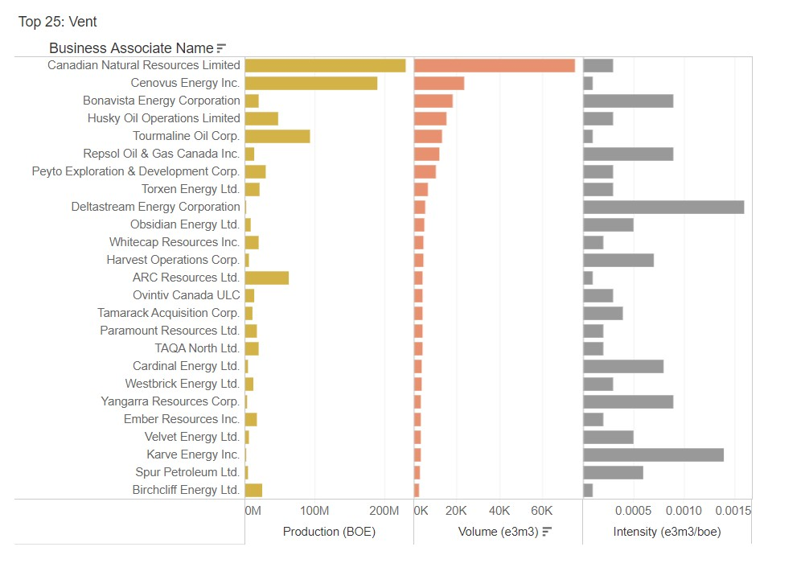

Canadian Oil Production Visualized, [graph credits to Carl Meyer](https://twitter.com/ottawacarl/status/1539610256162127872)

[Original Article](https://thenarwhal.ca/alberta-climate-methane-cnrl/)

## Shell’s Renewable Project in the Philippines

#### [Yousaff Habib](https://www.linkedin.com/in/yousaff-habib-6684891a5/)

A subdivision of Shell PLC, Shell Overseas Investments B.V. has just signed an agreement with Philippines Emerging Power Inc to build a 1 gigawatt (GW) solar power system, large enough to power roughly 1.2 million homes in the Philippines. Shell aims to become net zero by 2050, and this project is one of many that they have undertaken to reach this goal. The project can scale up to 3 GW, according to Shell. With 4.7 GW of renewable energy capacity currently on their books, this agreement will go a long way to advancing Shell’s emissions reduction goals. The London-based oil and gas giant is committing to similar initiatives in other countries as well, including funding research into renewables and the generation of green hydrogen. This push for sustainability is a sentiment being echoed across a number of companies, but Shell stands out in their commitment, perhaps in part because [Dutch courts have pushed them harder than others](https://www.nytimes.com/2021/05/26/business/royal-dutch-shell-climate-change.html).

For more information about the project, check out [this from Shell](https://www.shell.com.ph/motorists/inside-our-stations/next-generation-sustainability-now.html) as well as [this from Reuters](https://www.reuters.com/business/sustainable-business/shell-philippine-partner-build-1-gw-renewable-energy-capacity-2022-07-01/).

# Oil

## Weekly Crude Prices

### Feature Crude

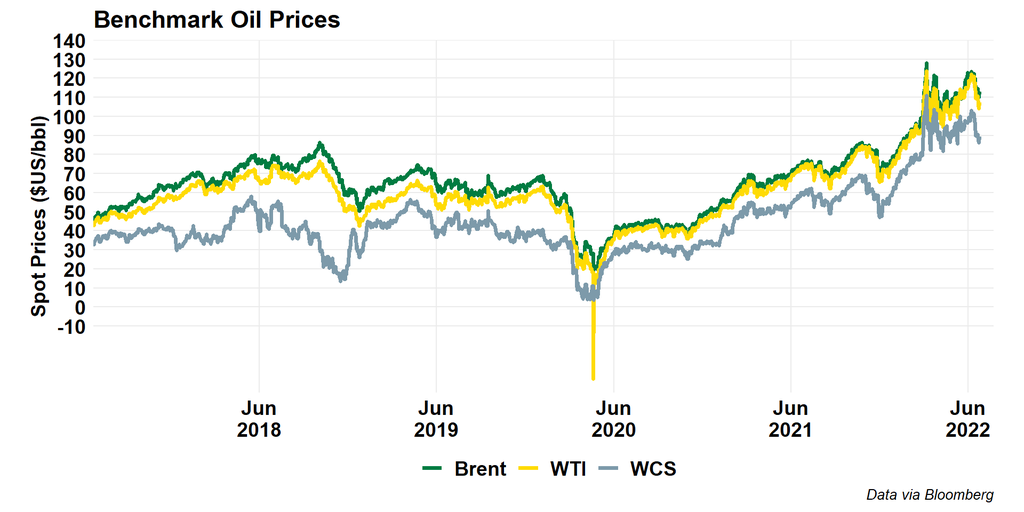

### Alberta Crude

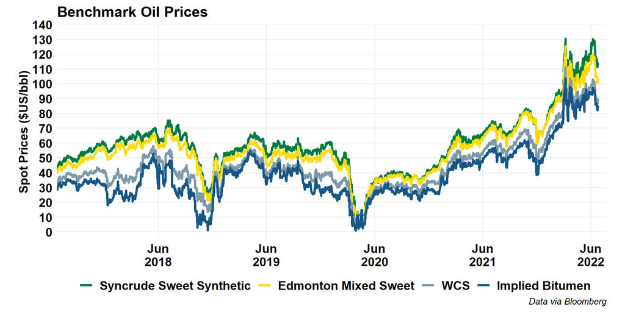

### Alberta Crude (Short)

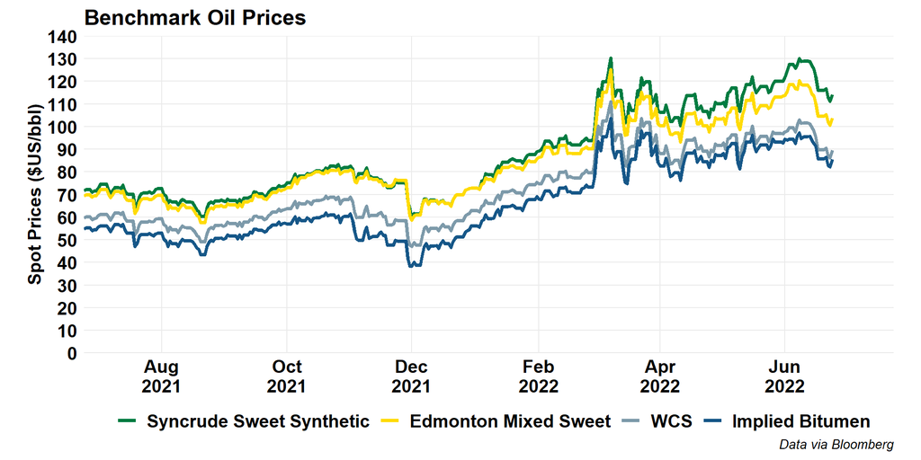

### US Crude

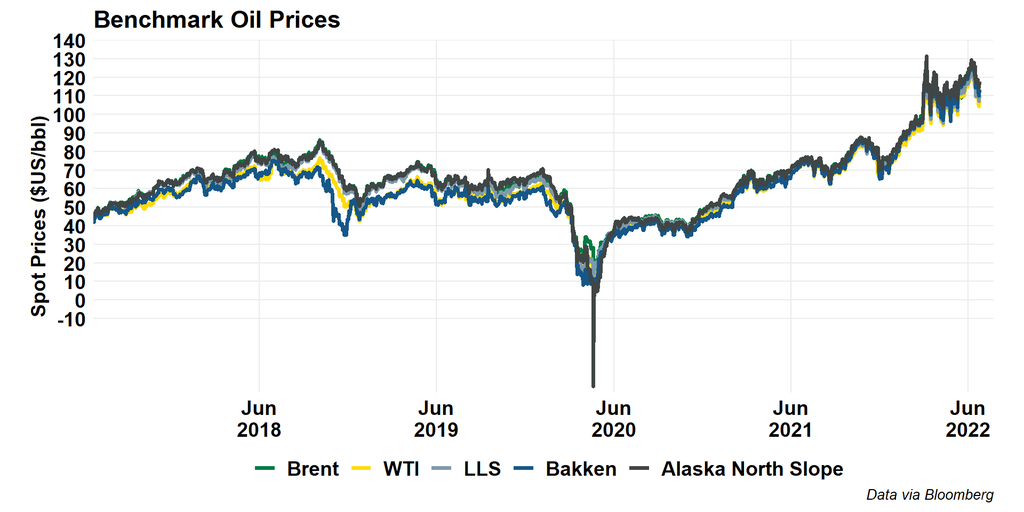

### Global Crude

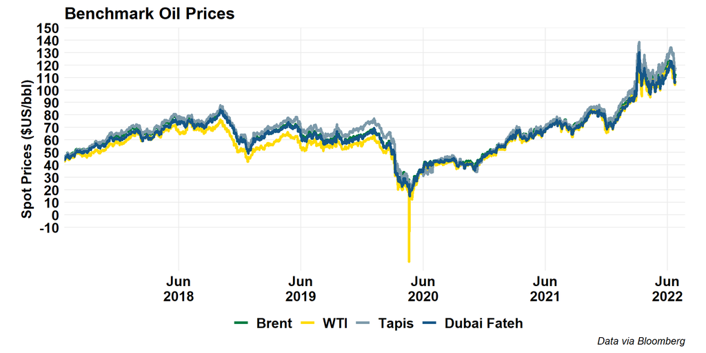

## Oil Price Differentials

### Brent-WTI

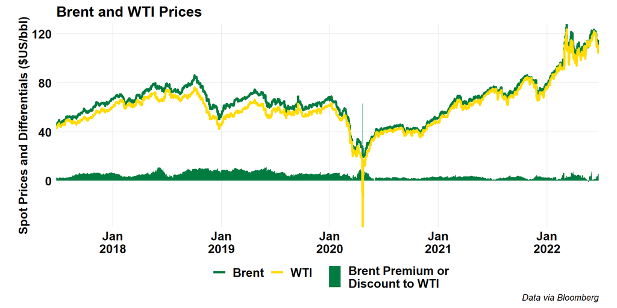

### WTI-WCS

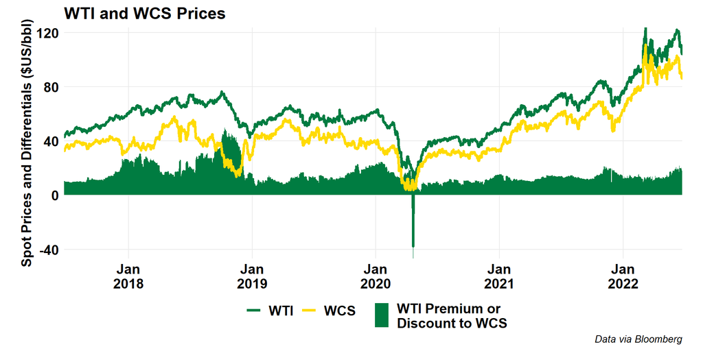

### WTI-WCS (Short)

[figure not shown]

### Maya-WCS

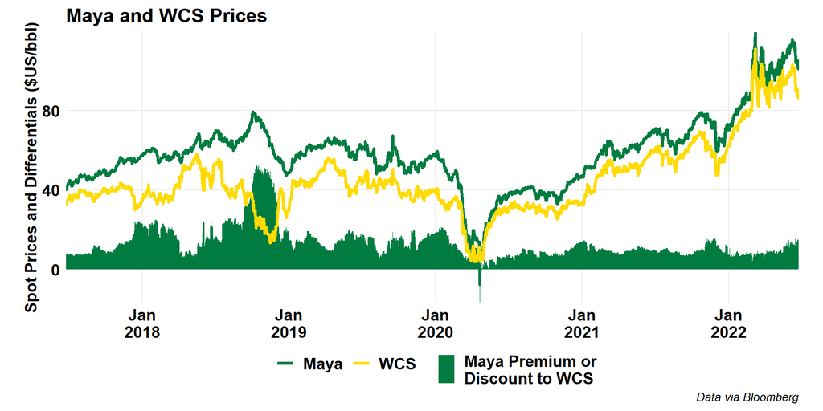

### WTI Cushing vs MEH

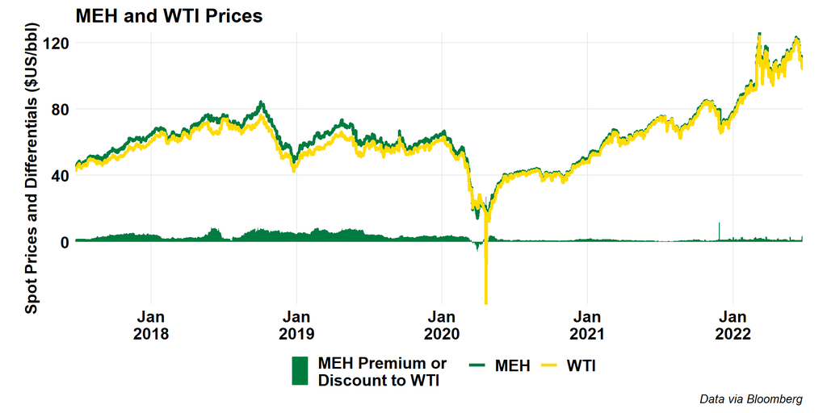

## Forward Curves

### WTI

[figure not shown]

### Brent

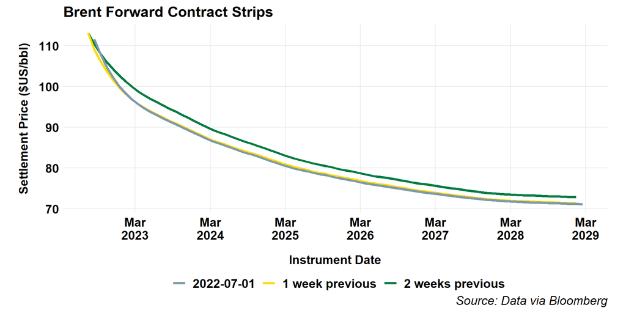